# Introduction : Data Visualisation

Le 26 avril 2022

## Plan du cours

- Manipulation de données (Dplyr)
- Fonction lapply
- Séries temporelles (quantmod et lubridates)

## Dplyr

Le principe de ce paquet est d’utiliser des fonctions de haut niveau de manipulation d’objet de données. La syntaxe et la philosophie de ce paquet est similaire au langage SQL.

Il permet de réduire dans la plupart des cas la taille du code écrit grâce à cet objet `%>%` (un opérateur assimilable au `+` dans ggplot2).

A l’instar de Ggplot, il possède une grammaire de manipulation de données. Les verbes (les fonctions) de ce paquet permettent de résoudre des problèmes communs de manipulation de données.

## Dplyr

Nous allons étudier les 5 fonctions de dplyr : `mutate()`, `filter()`, `select()`, `arrange()` et finalement `summarise()`

**Source :**

[Cours de data mining](https://laurentpolitis.github.io/FIN406_2017/docs/data-mining.html)

[Présentation et installation](https://dplyr.tidyverse.org/)

[Introduction](https://cran.r-project.org/web/packages/dplyr/vignettes/dplyr.htmls)

Cours interactif

## Apply function

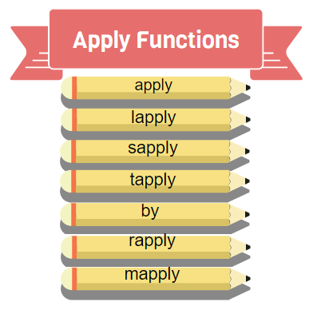

## Exemple d’une application

Le but de cet exemple est de télécharger le taux de change de l’euros avec d’autre devises et d’arranger les données sous forme de data.frame.

```r
library(tidyquant)
library(dplyr)
dt = c("EUR/USD", "EUR/JPY", "EUR/RUB") %>%
 tq_get( get = "alphavantage",
         av_fun = "FX_DAILY") %>%
  select("timestamp","symbol","high")

df_list = lapply(setNames(object = unique(dt$symbol),
                          nm = unique(dt$symbol)),
                 function(y) return( dt %>%
                   filter(y == symbol) %>%
                   dplyr::select("high")))

df_data = dplyr::bind_cols( df_list)
colnames(df_data) =  c("EUR/USD", "EUR/JPY", "EUR/RUB") # changement de noms des colonnes de la data frame

rownames(df_data) = (dt %>% filter("EUR/USD"==symbol))$timestamp
```

## Autre méthode

Il y a plusieurs méthodes ou chemins pour obtenir le même résultat. Pour ce faire, une autre manière de créer cette data frame et d’utiliser la fonction `tidyr::gather()`ou `tidyr::spread()`

```r
library(tidyquant)
library(tidyquant)
dt = c("EUR/USD", "EUR/JPY", "EUR/RUB") %>%
 tq_get( get = "alphavantage",
         av_fun = "FX_DAILY") %>%
  select("timestamp","symbol","high")

df_data = dt %>% tidyr::spread(symbol,high)

rownames(df_data) = dt$timestamp

head(df_data)
```

## Résulats

```
## # A tibble: 6 x 3
##   `EUR/USD` `EUR/JPY` `EUR/RUB`
##       <dbl>     <dbl>     <dbl>
## 1      1.14      129.      83.8
## 2      1.13      129.      83.6
## 3      1.13      128.      83.4
## 4      1.13      128.      83.3
## 5      1.13      129.      83.3
## 6      1.13      129.      83.7
```

## Apply

Calcul sur des données avec des structures matricielles :

**Moyenne par colonne**

```r
apply(X =df_data ,MARGIN = 2 ,FUN = mean)
apply(X =df_data ,MARGIN = 2 ,FUN = function(x) {mean(x)})
```

**Moyenne par ligne**

```r
apply(X =df_data ,MARGIN = 1 ,FUN = mean(x))
```

**Les 2**

```r
apply(X =df_data ,MARGIN = c(1,2) ,FUN = mean(x))
```

## Apply : Résultats

Calcul sur des données avec des structures matricielles :

**Moyenne par colonne**

```
##    EUR/USD    EUR/JPY    EUR/RUB
##   1.121218 131.886990  96.781415
```

**Moyenne par ligne**

```
## 2021-12-08 2021-12-09 2021-12-10 2021-12-13 2021-12-14
##   71.33883   71.28087   70.96480   70.94831   70.99943
```

**Les 2**

```
##            EUR/USD EUR/JPY EUR/RUB
## 2021-12-08 1.13548 129.126  83.755
## 2021-12-09 1.13460 129.071  83.637
```

## sapply et lapply

En fonction de la situation, vous pouvez utiliser soit sapply pour un format vectoriel et lapply pour des listes.

```r
head(sapply(df_data$`EUR/USD`, function(x)
  abs((x-mean(df_data$`EUR/USD`))/sd(df_data$`EUR/USD`))))
```

```
## [1] 0.7134096 0.6693896 0.5598398 0.5358288 0.5593395 0.4357833
```

```r
head(lapply(df_data$`EUR/USD`, function(x)
  abs((x-mean(df_data$`EUR/USD`))/sd(df_data$`EUR/USD`))))
```

```
## [[1]]
## [1] 0.7134096
##
## [[2]]
## [1] 0.6693896
##
## [[3]]
## [1] 0.5598398
##
## [[4]]
## [1] 0.5358288
##
## [[5]]
## [1] 0.5593395
##
## [[6]]
## [1] 0.4357833
```

## Parallelisation

Si vous souhaitez augmenter la vitesse de votre code, vous pouvez utiliser le package parallel sur linux.

```r
library(parallel)
n = 1
time = Sys.time()
a = mclapply(df_data$`EUR/USD`, FUN = function(x)
  abs((x-mean(df_data$`EUR/USD`))/sd(df_data$`EUR/USD`)),
  mc.cores =n)

print(paste("Avec Parallelisation",Sys.time()-time))
```

```
## [1] "Avec Parallelisation 0.0169260501861572"
```

## Analyses Séries Temporelles

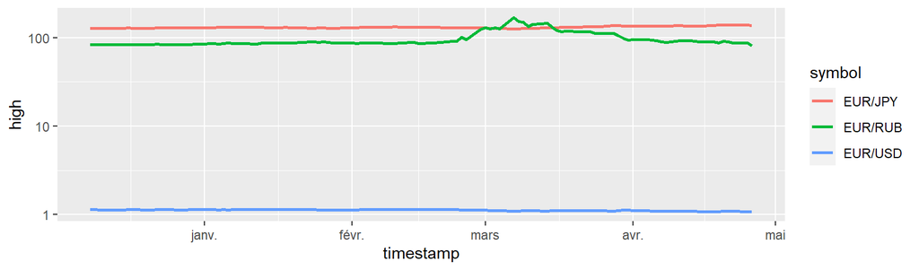

```r
library(ggplot2)

ggplot(dt) + geom_line(aes(x = timestamp,y = high,color=symbol),size=1)+
  scale_y_log10()
```

## Analyses Séries Temporelles

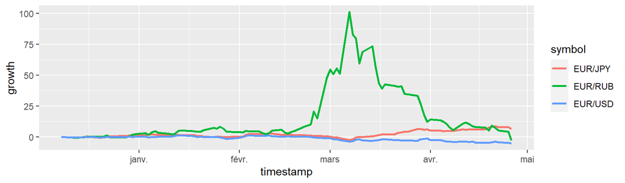

```r
library(ggplot2)
library(lubridate)

dt = dt %>% group_by(symbol) %>% mutate(growth = (high
              - first(high))/first(high)*100)

ggplot(dt) + geom_line(aes(x = timestamp,y = growth,color=symbol),size=1)
```